# Milo workflow on Gg_ctrl_poly_int

Fabio Sacher

07.02.2023

```r
library(miloR, quietly = TRUE)
library(SingleCellExperiment, quietly = TRUE)
library(scater, quietly = TRUE)
library(dplyr)
library(patchwork)
library(Seurat)
library(stringr)
library(patchwork)
library(ggplot2)
```

# Introduction

Milo is a tool for analysis of complex single cell datasets generated from replicated multi-condition experiments, which detects changes in composition between conditions. While differential abundance (DA) is commonly quantified in discrete cell clusters, Milo uses partally overlapping neighbourhoods of cells on a KNN graph. Starting from a graph that faithfully recapitulates the biology of the cell population, Milo analysis consists of 3 steps:

- Sampling of representative neighbourhoods
- Testing for differential abundance of conditions in all neighbourhoods
- Accounting for multiple hypothesis testing using a weighted FDR procedure that accounts for the overlap of neighbourhoods

In this vignette we will elaborate on how these steps are implemented in the miloR package.

# From Seurat object

The Seurat package includes a converter to SingleCellExperiment.

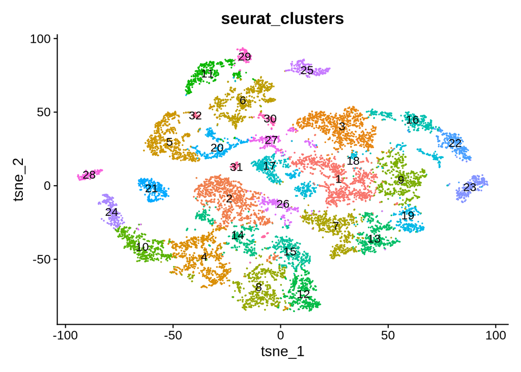

```r
my.seed <- 07022023

my.se <- readRDS("~/spinal_cord_paper/data/Gg_ctrl_poly_int_seurat_250723.rds")

my.se$cond <- substr(my.se$orig.ident, 1, 4)
# represents the sequencing batch as well
my.se$batch <- my.se$orig.ident

dim1 <- DimPlot(my.se,
                reduction = "tsne",
                group.by = "seurat_clusters",
                label = TRUE) + NoLegend()
dim1
```

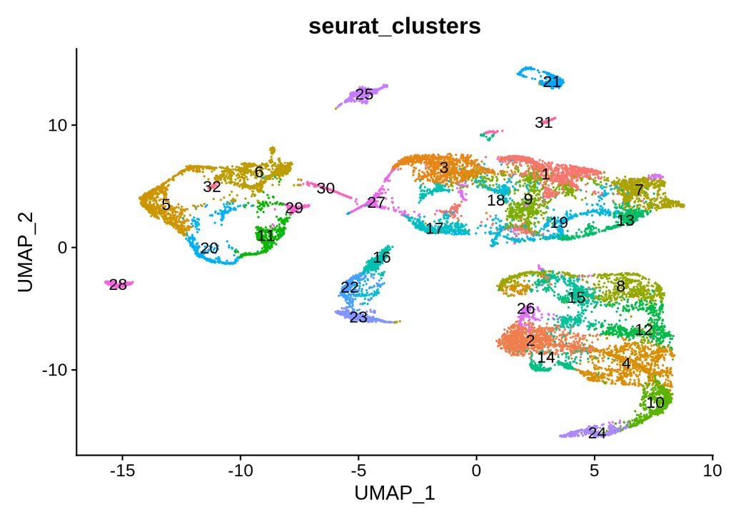

```r
dim2 <- DimPlot(my.se,
                reduction = "umap",
                group.by = "seurat_clusters",
                label = TRUE) + NoLegend()
dim2
```

```r
my.sce <- as.SingleCellExperiment(my.se)
my.milo <- Milo(my.sce)
```

# Pre-processing

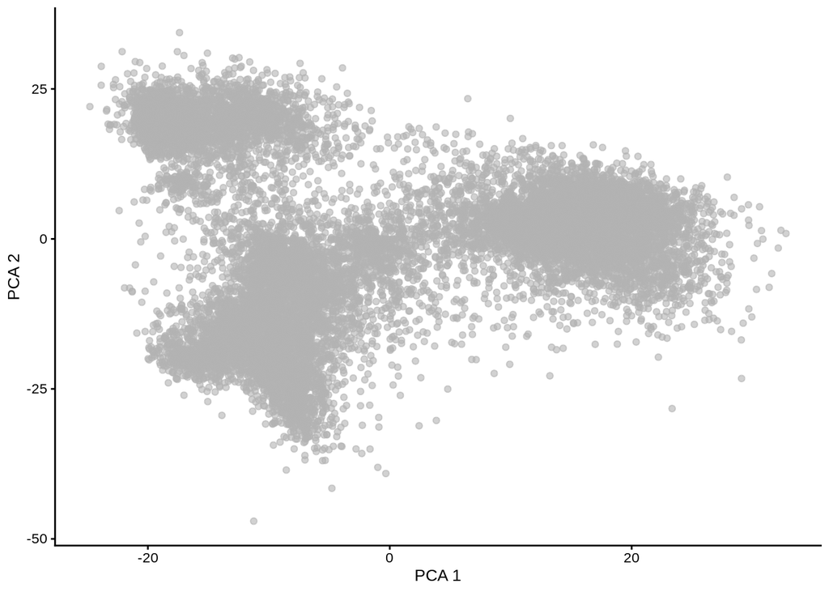

```r
pca <- plotPCA(my.milo)
tsne <- plotTSNE(my.milo)

pca
```

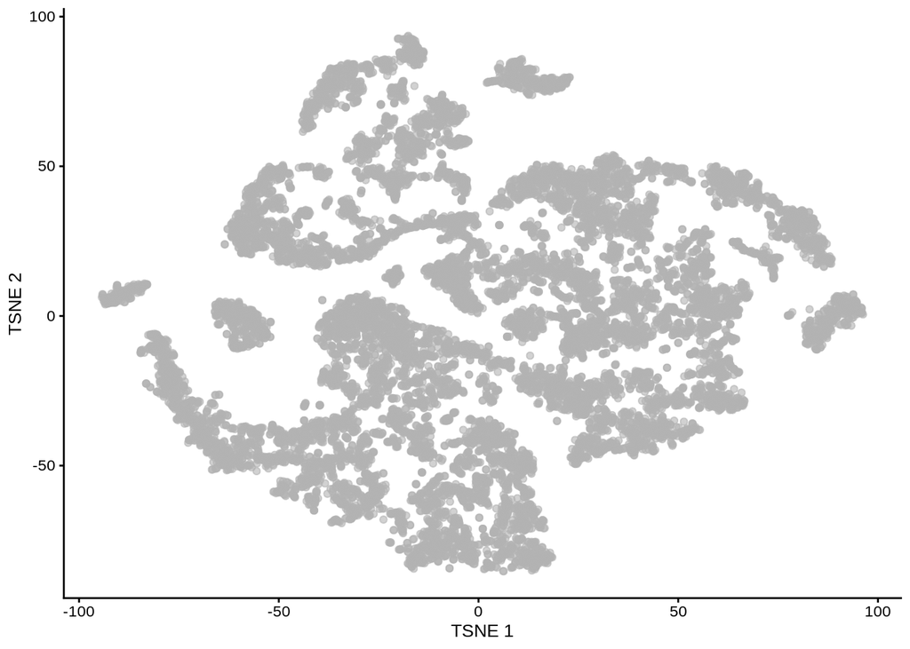

```r
tsne
```

```r
my.milo
```

```
## class: Milo
## dim: 3000 14937
## metadata(0):
## assays(1): logcounts
## rownames(3000): ENSGALG00000003193 ENSGALG00000007796 ...
##   ENSGALG00000016314 ENSGALG00000016392
## rowData names(0):
## colnames(14937): AAACCCAAGCTGTTAC-1_1 AAACCCACATTGACCA-1_1 ...
##   TTTGTTGGTTAGCTAC-1_4 TTTGTTGTCCACCCTA-1_4
## colData names(18): orig.ident nCount_RNA ... batch ident
## reducedDimNames(3): PCA UMAP TSNE
## mainExpName: integrated
## altExpNames(0):
## nhoods dimensions(2): 1 1
## nhoodCounts dimensions(2): 1 1
## nhoodDistances dimension(1): 0
## graph names(0):
## nhoodIndex names(1): 0
## nhoodExpression dimension(2): 1 1
## nhoodReducedDim names(0):
## nhoodGraph names(0):
## nhoodAdjacency dimension(2): 1 1
```

# Construct KNN graph

We need to add the KNN graph to the Milo object. This is stored in the graph slot, in igraph format. The miloR package includes functionality to build and store the graph from the PCA dimensions stored in the reducedDim slot.

```r
set.seed(my.seed)
my.milo <- buildGraph(my.milo, k = 10, d = 30)
```

```
## Constructing kNN graph with k:10
```

# 1. Defining representative neighbourhoods

We define the neighbourhood of a cell, the index, as the group of cells connected by an edge in the KNN graph to the index cell. For efficiency, we don’t test for DA in the neighbourhood of every cell, but we sample as indices a subset of representative cells, using a KNN sampling algorithm used by Gut et al. 2015.

For sampling you need to define a few parameters:

```
prop: the proportion of cells to randomly sample to start with (usually 0.1 - 0.2 is sufficient)
k: the k to use for KNN refinement (we recommend using the same k used for KNN graph building)
d: the number of reduced dimensions to use for KNN refinement (we recommend using the same d used for KNN graph building)
refined indicated whether you want to use the sampling refinement algorith, or just pick cells at random. The default and recommended way to go is to use refinement. The only situation in which you might consider using random instead, is if you have batch corrected your data with a graph based correction algorithm, such as BBKNN, but the results of DA testing will be suboptimal.
```

```r
set.seed(my.seed)
my.milo <- makeNhoods(my.milo, prop = 0.1, k = 10, d=30, refined = TRUE)
```

```
## Checking valid object
```

Once we have defined neighbourhoods, it’s good to take a look at how big the neighbourhoods are (i.e. how many cells form each neighbourhood). This affects the power of DA testing. We can check this out using the plotNhoodSizeHist function. Empirically, we found it’s best to have a distribution peaking between 50 and 100. Otherwise you might consider rerunning makeNhoods increasing k and/or prop (here the distribution looks ludicrous because it’s a small dataset).

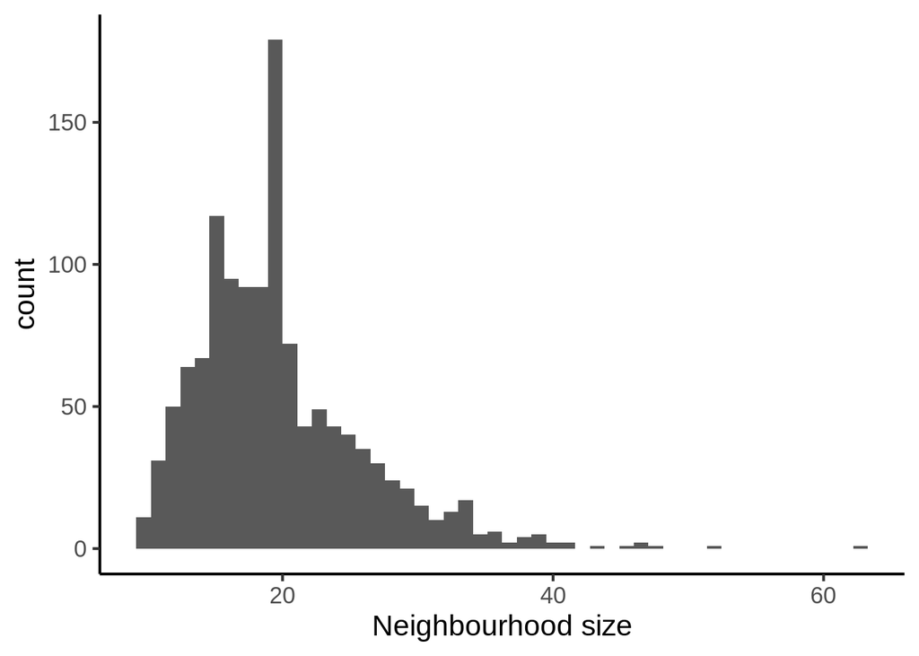

```r
plotNhoodSizeHist(my.milo)
```

## Counting cells in neighbourhoods

Now we have to count how many cells from each sample are in each neighbourhood. We need to use the cell metadata and specify which column contains the sample information.

```r
my.milo <- countCells(
              my.milo,
              meta.data = data.frame(colData(my.milo)),
              sample = "orig.ident"
              )
```

```
## Checking meta.data validity
```

```
## Counting cells in neighbourhoods
```

```r
head(nhoodCounts(my.milo))
```

```
## 6 x 4 sparse Matrix of class "dgCMatrix"
##   Gg_ctrl_1 Gg_ctrl_2 Gg_poly_1 Gg_poly_2
## 1         9         2         3         8
## 2         6         9         5         7
## 3         .         8         7         6
## 4         2        11         2         5
## 5         2         8         5         5
## 6         3         4         2         4
```

## Differential abundance testing

Now we are all set to test for differential abundance in neighbourhoods. We implement this hypothesis testing in a generalized linear model (GLM) framework, specifically using the Negative Binomial GLM implementation in edgeR.

We first need to think about our experimental design. The design matrix should match samples to a condition of interest. In this case the Condition is the covariate we are going to test for.

```r
my.design <- data.frame(colData(my.milo))[,c("orig.ident", "cond", "batch")]
my.design <- distinct(my.design)
rownames(my.design) <- my.design[, "orig.ident"]

my.design
```

|  | orig.ident | cond | batch |
| --- | --- | --- | --- |
| Gg_ctrl_1 | Gg_ctrl_1 | Gg_c | Gg_ctrl_1 |
| Gg_ctrl_2 | Gg_ctrl_2 | Gg_c | Gg_ctrl_2 |
| Gg_poly_1 | Gg_poly_1 | Gg_p | Gg_poly_1 |
| Gg_poly_2 | Gg_poly_2 | Gg_p | Gg_poly_2 |

Milo uses an adaptation of the Spatial FDR correction introduced by cydar, which accounts for the overlap between neighbourhoods. Specifically, each hypothesis test P-value is weighted by the reciprocal of the kth nearest neighbour distance. To use this statistic we first need to store the distances between nearest neighbors in the Milo object.

```r
my.milo <- calcNhoodDistance(my.milo, d=30)
```

Now we can do the test, explicitly defining our experimental design. We want to test for differences between experimental contitions.

```r
da.results <- testNhoods(my.milo, design = ~ cond, design.df = my.design)
```

```
## Using TMM normalisation
```

```
## Performing spatial FDR correction withk-distance weighting
```

This calculates a Fold-change and corrected P-value for each neighbourhood, which indicates wheather there is significant differential abundance between conditions.

```r
da.results %>%
  arrange(- SpatialFDR) %>%
  head()
```

|  | logFC | logCPM | F | PValue | FDR | Nhood | SpatialFDR |
| --- | --- | --- | --- | --- | --- | --- | --- |
| 872 | -0.001065129 | 10.320754 | 4.046090e-06 | 0.9983973 | 0.9987981 | 872 | 0.9987981 |
| 1052 | -0.001557690 | 10.066608 | 2.275540e-06 | 0.9987981 | 0.9987981 | 1052 | 0.9987981 |
| 664 | 0.005984616 | 9.725220 | 1.421752e-05 | 0.9969957 | 0.9987890 | 664 | 0.9987364 |
| 722 | 0.005984616 | 9.725220 | 1.421752e-05 | 0.9969957 | 0.9987890 | 722 | 0.9987364 |
| 800 | -0.003313380 | 9.909618 | 1.250964e-05 | 0.9971820 | 0.9987890 | 800 | 0.9987364 |
| 1 | -0.070250597 | 10.346135 | 5.077284e-03 | 0.9432928 | 0.9970175 | 1 | 0.9962575 |

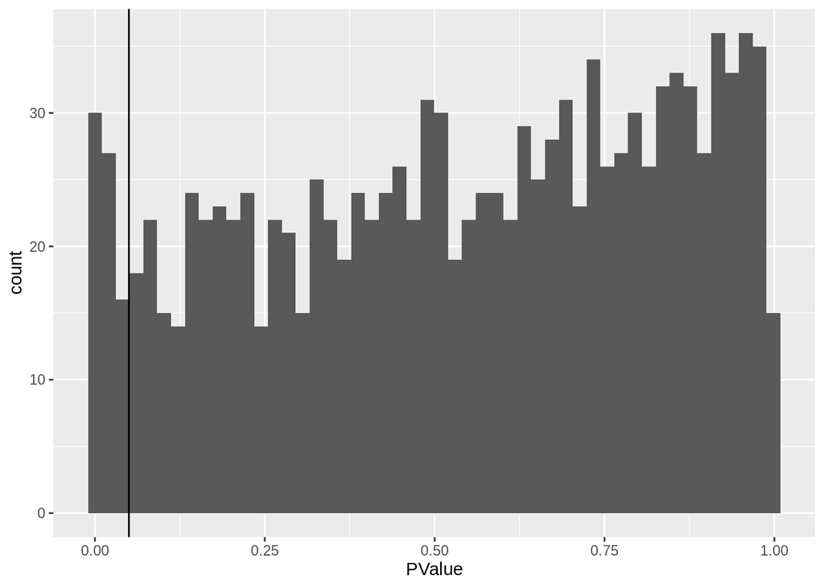

```r
res_1 <- ggplot(da.results, aes(PValue)) +
  geom_histogram(bins=50) +
  geom_vline(xintercept = 0.05)
res_1
```

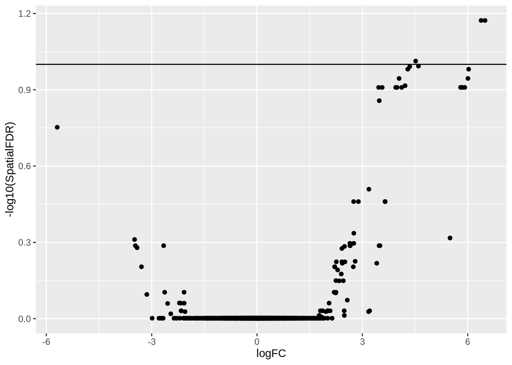

```r
res_2 <- ggplot(da.results, aes(logFC, -log10(SpatialFDR))) +
  geom_point() +
  geom_hline(yintercept = 1) ## Mark significance threshold (10% FDR)
res_2
```

## Visualize neighbourhoods displaying DA

To visualize DA results, we build an abstracted graph of neighbourhoods that we can superimpose on the single-cell embedding.

```r
set.seed(my.seed)
my.milo <- buildNhoodGraph(my.milo)
```

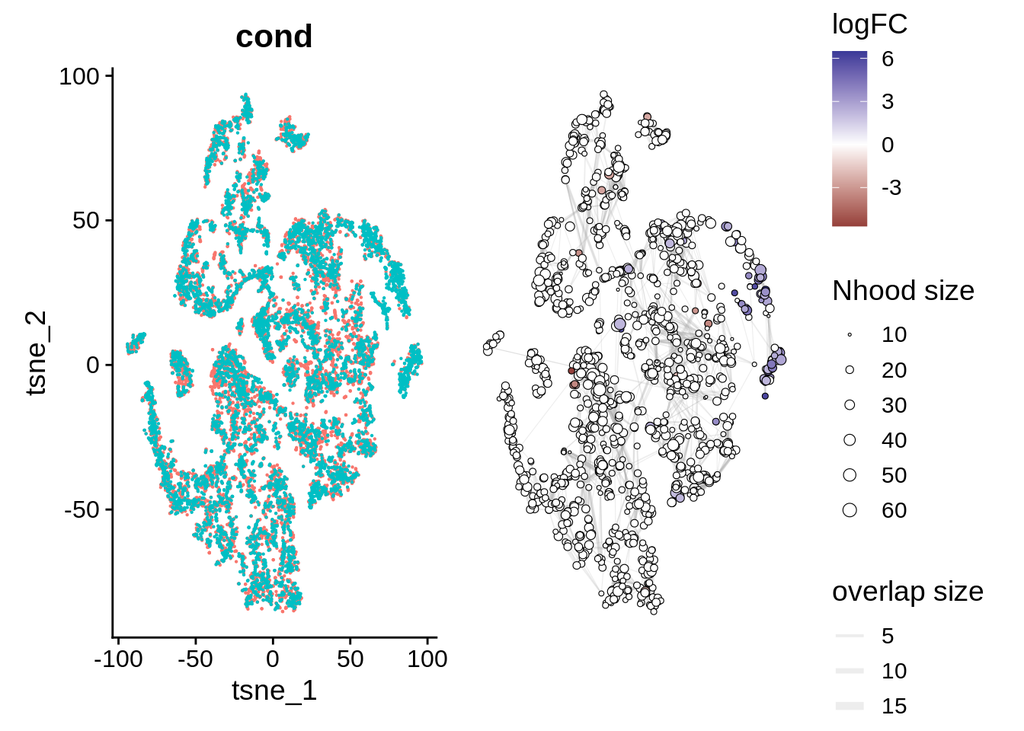

```r
DimPlot(my.se,
        reduction = "tsne",
        group.by = "cond") +
  plotNhoodGraphDA(my.milo, da.results, alpha=0.9, layout = "TSNE") +
  plot_layout(guides="collect")
```

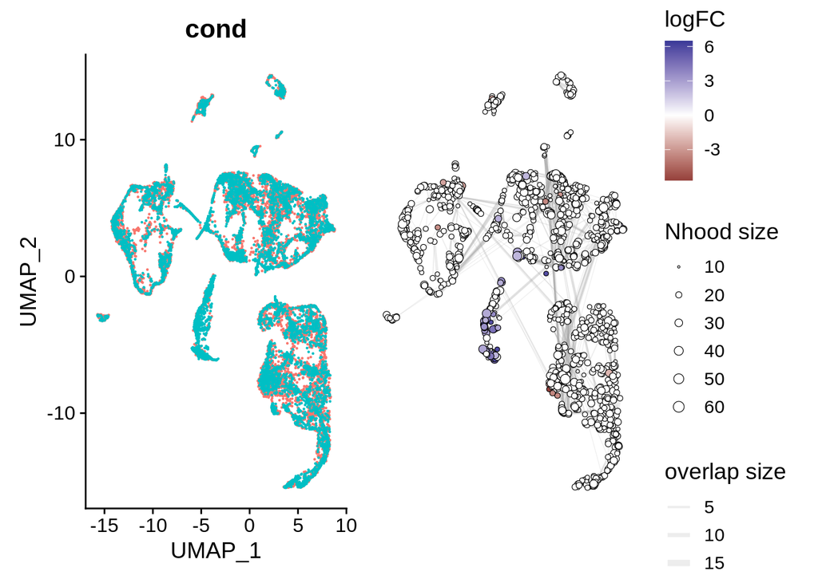

```r
DimPlot(my.se,
        reduction = "umap",
        group.by = "cond") +
  plotNhoodGraphDA(my.milo, da.results, alpha=0.9, layout = "UMAP") +
  plot_layout(guides="collect")
```

## annotate neighbourhoods

We might also be interested in visualizing wheather DA is particularly evident in certain cell types. To do this, we assign a cell type label to each neighbourhood by finding the most abundant cell type within cells in each neighbourhood. We can label neighbourhoods in the results data.frame using the function annotateNhoods. This also saves the fraction of cells harbouring the label.

```r
da.results <- annotateNhoods(my.milo, da.results, coldata_col = "seurat_clusters")
head(da.results)
```

|  | logFC | logCPM | F | PValue | FDR | Nhood | SpatialFDR | seurat_clusters | seurat_clusters_fraction |
| --- | --- | --- | --- | --- | --- | --- | --- | --- | --- |
| 1 | -0.0702506 | 10.346135 | 0.005077284 | 0.9432928 | 0.9970175 | 1 | 0.9962575 | 8 | 1.00 |
| 2 | -0.1788501 | 10.506280 | 0.041723591 | 0.8383826 | 0.9970175 | 2 | 0.9962575 | 12 | 1.00 |
| 3 | 0.9972884 | 10.209157 | 1.066602818 | 0.3035268 | 0.9970175 | 3 | 0.9962575 | 20 | 1.00 |
| 4 | -0.6492474 | 10.111631 | 0.465467682 | 0.4959728 | 0.9970175 | 4 | 0.9962575 | 20 | 0.75 |
| 5 | 0.2370579 | 10.161839 | 0.063782774 | 0.8009075 | 0.9970175 | 5 | 0.9962575 | 14 | 1.00 |
| 6 | -0.1076445 | 9.765993 | 0.008424326 | 0.9269735 | 0.9970175 | 6 | 0.9962575 | 9 | 1.00 |

While neighbourhoods tend to be homogeneous, we can define a threshold for celltype_fraction to exclude neighbourhoods that are a mix of cell types.

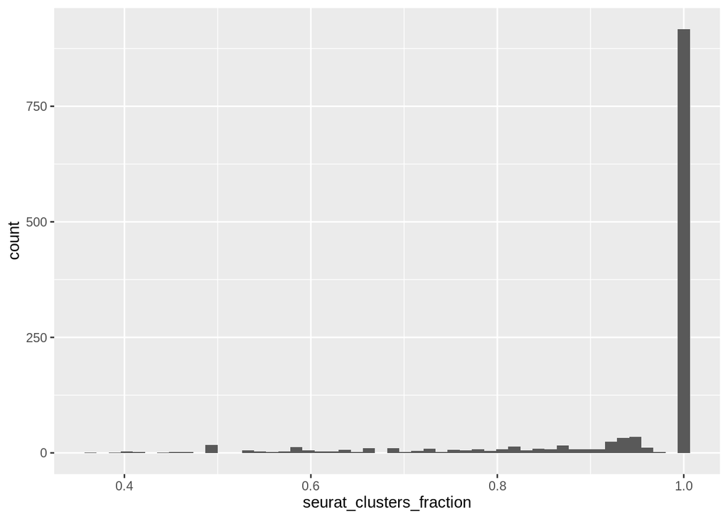

```r
ggplot(da.results, aes(seurat_clusters_fraction)) + geom_histogram(bins=50)
```

```r
da.results$seurat_clusters <- ifelse(da.results$seurat_clusters_fraction < 0.95, "Mixed", da.results$seurat_clusters)
```

Plot logFC of the nhoods by cell type (cluster):

```
## Converting group.by to factor...
```

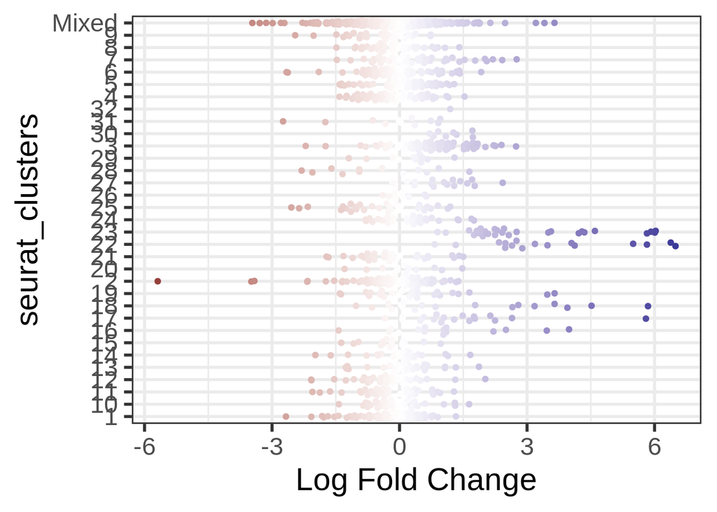

```r
plotDAbeeswarm(da.results, group.by = "seurat_clusters", alpha=1.0)
```

#export

```r
saveRDS(my.milo, paste0("~/spinal_cord_paper/output/",my.se@project.name ,"_milo_",format(Sys.Date(), "%d%m%y"),".rds"))

# pdf export figures
pdf(paste0("~/spinal_cord_paper/figures/",my.se@project.name ,"_milo_",format(Sys.Date(), "%d%m%y"),".pdf"), width = 5, height = 5)

dim1 + ggtitle(my.se@project.name)
dim2 + ggtitle(my.se@project.name)
pca + ggtitle(my.se@project.name)
res_1
res_2
DimPlot(my.se,
        reduction = "tsne",
        group.by = "cond")
plotNhoodGraphDA(my.milo,
                 da.results,
                 alpha=0.9,
                 layout = "TSNE") + NoLegend()

DimPlot(my.se,
        reduction = "umap",
        group.by = "cond")
plotNhoodGraphDA(my.milo,
                 da.results,
                 alpha=0.9,
                 layout = "UMAP")

plotNhoodSizeHist(my.milo)

ggplot(da.results, aes(seurat_clusters_fraction)) + geom_histogram(bins=50)

plotDAbeeswarm(da.results, group.by = "seurat_clusters", alpha=1.0)
```

```
## Converting group.by to factor...
```

```r
dev.off()
```

```r
# Date and time of Rendering
Sys.time()
```

```
## [1] "2023-08-10 16:31:56 CEST"
```